# Models: inference and prediction

linear regression and {tidymodels}

Author

Affiliations

John Little

[Duke University Libraries](https://library.duke.edu/data)

Center for Data & Visualization Sciences

Published

January 8, 2024

**Models**

All models are wrong, but some are useful — George Box

## Resources

- https://tellingstorieswithdata.com/
- https://moderndive.com/
- https://www.tidymodels.org/start/

## Load library packages

```r
library(tidyverse)
library(moderndive)
library(broom)
library(skimr)
# library(tidymodels)
library(arrow)
```

## Import data

Data from *Modern Dive* (Lipovetsky 2020)

```r
evals_ch5 <- evals %>%
  select(ID, score, bty_avg, age, gender)

evals
```

| ID | prof_ID | score | age | bty_avg | gender | ethnicity | language | rank | pic_outfit | pic_color | cls_did_eval | cls_students | cls_level |
| --- | --- | --- | --- | --- | --- | --- | --- | --- | --- | --- | --- | --- | --- |
| 1 | 1 | 4.7 | 36 | 5.000 | female | minority | english | tenure track | not formal | color | 24 | 43 | upper |
| 2 | 1 | 4.1 | 36 | 5.000 | female | minority | english | tenure track | not formal | color | 86 | 125 | upper |
| 3 | 1 | 3.9 | 36 | 5.000 | female | minority | english | tenure track | not formal | color | 76 | 125 | upper |
| 4 | 1 | 4.8 | 36 | 5.000 | female | minority | english | tenure track | not formal | color | 77 | 123 | upper |
| 5 | 2 | 4.6 | 59 | 3.000 | male | not minority | english | tenured | not formal | color | 17 | 20 | upper |
| 6 | 2 | 4.3 | 59 | 3.000 | male | not minority | english | tenured | not formal | color | 35 | 40 | upper |
| 7 | 2 | 2.8 | 59 | 3.000 | male | not minority | english | tenured | not formal | color | 39 | 44 | upper |
| 8 | 3 | 4.1 | 51 | 3.333 | male | not minority | english | tenured | not formal | color | 55 | 55 | upper |
| 9 | 3 | 3.4 | 51 | 3.333 | male | not minority | english | tenured | not formal | color | 111 | 195 | upper |
| 10 | 4 | 4.5 | 40 | 3.167 | female | not minority | english | tenured | not formal | color | 40 | 46 | upper |

[output cut: 453 more lines]

### Summarize data

```r
evals_ch5 |>
  summary()
```

```
       ID            score          bty_avg           age           gender
 Min.   :  1.0   Min.   :2.300   Min.   :1.667   Min.   :29.00   female:195
 1st Qu.:116.5   1st Qu.:3.800   1st Qu.:3.167   1st Qu.:42.00   male  :268
 Median :232.0   Median :4.300   Median :4.333   Median :48.00
 Mean   :232.0   Mean   :4.175   Mean   :4.418   Mean   :48.37
 3rd Qu.:347.5   3rd Qu.:4.600   3rd Qu.:5.500   3rd Qu.:57.00
 Max.   :463.0   Max.   :5.000   Max.   :8.167   Max.   :73.00
```

### Skim data (EDA)

```r
skimr::skim(evals_ch5)
```

Data summary

| Name | evals_ch5 |
| --- | --- |
| Number of rows | 463 |
| Number of columns | 5 |
| _______________________ |  |
| Column type frequency: |  |
| factor | 1 |
| numeric | 4 |
| ________________________ |  |
| Group variables | None |

**Variable type: factor**

| skim_variable | n_missing | complete_rate | ordered | n_unique | top_counts |
| --- | --- | --- | --- | --- | --- |
| gender | 0 | 1 | FALSE | 2 | mal: 268, fem: 195 |

**Variable type: numeric**

| skim_variable | n_missing | complete_rate | mean | sd | p0 | p25 | p50 | p75 | p100 | hist |
| --- | --- | --- | --- | --- | --- | --- | --- | --- | --- | --- |
| ID | 0 | 1 | 232.00 | 133.80 | 1.00 | 116.50 | 232.00 | 347.5 | 463.00 | ▇▇▇▇▇ |
| score | 0 | 1 | 4.17 | 0.54 | 2.30 | 3.80 | 4.30 | 4.6 | 5.00 | ▁▁▅▇▇ |
| bty_avg | 0 | 1 | 4.42 | 1.53 | 1.67 | 3.17 | 4.33 | 5.5 | 8.17 | ▃▇▇▃▂ |
| age | 0 | 1 | 48.37 | 9.80 | 29.00 | 42.00 | 48.00 | 57.0 | 73.00 | ▅▆▇▆▁ |

## Correlation

```r
my_cor_df <- starwars |>
  filter(mass < 500) |>
  summarise(my_cor = cor(height, mass))

my_cor_df
```

| my_cor |
| --- |
| 0.7508582 |

## Linear regression

### `geom_smooth()`

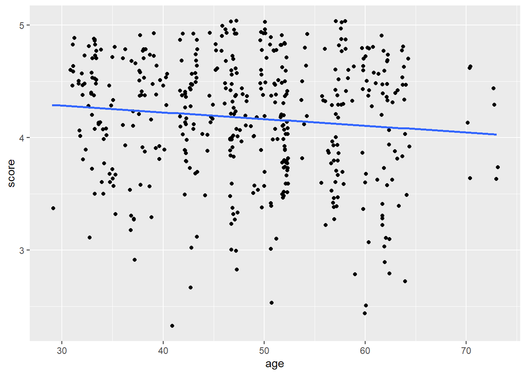

```r
evals_ch5 %>%
  ggplot(aes(age, score)) +  # color = gender
  geom_jitter() +
  geom_smooth(method = lm, formula = y ~ x, se = FALSE)
```

### `lm()` model

linear regression model

predict `score` from `bty_avg`

```r
evals_ch5 |>
  select(score, bty_avg)
```

| score | bty_avg |
| --- | --- |
| 4.7 | 5.000 |
| 4.1 | 5.000 |
| 3.9 | 5.000 |
| 4.8 | 5.000 |
| 4.6 | 3.000 |
| 4.3 | 3.000 |
| 2.8 | 3.000 |
| 4.1 | 3.333 |
| 3.4 | 3.333 |
| 4.5 | 3.167 |

[output cut: 453 more lines]

```r
# Fit regression model:
score_model <- lm(score ~ bty_avg, data = evals_ch5)

score_model
```

```
Call:
lm(formula = score ~ bty_avg, data = evals_ch5)

Coefficients:
(Intercept)      bty_avg
    3.88034      0.06664
```

### {broom} tidy the model

```r
broom::tidy(score_model)
```

| term | estimate | std.error | statistic | p.value |
| --- | --- | --- | --- | --- |
| (Intercept) | 3.88033795 | 0.07614297 | 50.961212 | 1.561043e-191 |
| bty_avg | 0.06663704 | 0.01629115 | 4.090382 | 5.082731e-05 |

### {broom} glance

Evaluate the model

```r
broom::glance(score_model)
```

| r.squared | adj.r.squared | sigma | statistic | p.value | df | logLik | AIC | BIC | deviance | df.residual | nobs |
| --- | --- | --- | --- | --- | --- | --- | --- | --- | --- | --- | --- |
| 0.03502226 | 0.03292903 | 0.5348351 | 16.73123 | 5.082731e-05 | 1 | -366.2225 | 738.4449 | 750.8581 | 131.8684 | 461 | 463 |

the fitted inference and the residuals

```r
broom::augment(score_model)
```

| score | bty_avg | .fitted | .resid | .hat | .sigma | .cooksd | .std.resid |
| --- | --- | --- | --- | --- | --- | --- | --- |
| 4.7 | 5.000 | 4.213523 | 0.486476860 | 0.002474270 | 0.5349343 | 1.028616e-03 | 0.910710268 |
| 4.1 | 5.000 | 4.213523 | -0.113523140 | 0.002474270 | 0.5353899 | 5.601417e-05 | -0.212521288 |
| 3.9 | 5.000 | 4.213523 | -0.313523140 | 0.002474270 | 0.5352160 | 4.272364e-04 | -0.586931807 |
| 4.8 | 5.000 | 4.213523 | 0.586476860 | 0.002474270 | 0.5347157 | 1.494964e-03 | 1.097915527 |
| 4.6 | 3.000 | 4.080249 | 0.519750934 | 0.004025008 | 0.5348652 | 1.915979e-03 | 0.973758273 |
| 4.3 | 3.000 | 4.080249 | 0.219750934 | 0.004025008 | 0.5353177 | 3.425008e-04 | 0.411705446 |
| 2.8 | 3.000 | 4.080249 | -1.280249066 | 0.004025008 | 0.5320648 | 1.162489e-02 | -2.398558689 |
| 4.1 | 3.333 | 4.102439 | -0.002439199 | 0.003251767 | 0.5354161 | 3.403871e-08 | -0.004568089 |
| 3.4 | 3.333 | 4.102439 | -0.702439199 | 0.003251767 | 0.5344102 | 2.822904e-03 | -1.315515897 |
| 4.5 | 3.167 | 4.091377 | 0.408622549 | 0.003611506 | 0.5350758 | 1.061710e-03 | 0.765399326 |

[output cut: 453 more lines]

## Nesting data to iterate models by category

```r
fit_my_lm <- function(mydf) {
  lm(mass ~ height, data = mydf)
}

starwars |>
  drop_na(mass, height, gender) |>
  nest(my_data = -gender) |>
  mutate(my_model = map(my_data, fit_my_lm)) |>
  mutate(my_model = map(my_model, tidy)) |>
  unnest(my_model)
```

| gender | my_data | term | estimate | std.error | statistic | p.value |
| --- | --- | --- | --- | --- | --- | --- |
| masculine |  | (Intercept) | -2.4166453 | 126.1537112 | -0.01915636 | 0.9848011 |
| masculine |  | height | 0.6243637 | 0.7055299 | 0.88495712 | 0.3808841 |
| feminine |  | (Intercept) | 82.8592914 | 49.4930816 | 1.67415907 | 0.1380119 |
| feminine |  | height | -0.1642057 | 0.2879679 | -0.57022219 | 0.5863550 |

## Putting it all together

from day 1

```r
library(tidyverse)

my_iterations <- evals |>
  janitor::clean_names() |>
  nest(data = -gender) |>
  mutate(cor_age = map_dbl(data, \(data) cor(data$score, data$age))) |>
  mutate(cor_bty = map_dbl(data, \(data) cor(data$score, data$bty_avg)))  |>
  mutate(my_fit_bty = map(data, \(data) lm(score ~ bty_avg, data = data) |>
                            broom::tidy())) |>
  mutate(my_plot = map(data, \(data) ggplot(data, aes(bty_avg, score)) +
                         geom_point(aes(color = age)) +
                         geom_smooth(method = lm,
                                     se = FALSE,
                                     formula = y ~ x))) |>
  mutate(my_plot = map2(my_plot, gender, \(my_plot, gender) my_plot +
                          labs(title = str_to_title(gender))))  |>
  mutate(my_plot_age = map(data, \(x) {
    x |>
      ggplot(aes(age, score)) +
      geom_point(aes(color = age)) +
      geom_smooth(method = glm,
                  se = FALSE,
                  formula = y ~ x)
    })) |>
  mutate(my_plot_age = map2(my_plot_age, gender, \(x, y) {
    x +
      labs(title = str_to_title(y))
  }))

my_iterations
```

| gender | data | cor_age | cor_bty | my_fit_bty | my_plot | my_plot_age |
| --- | --- | --- | --- | --- | --- | --- |
| female |  | -0.26517575 | 0.08547868 |  |  |  |
| male |  | -0.07645422 | 0.31093697 |  |  |  |

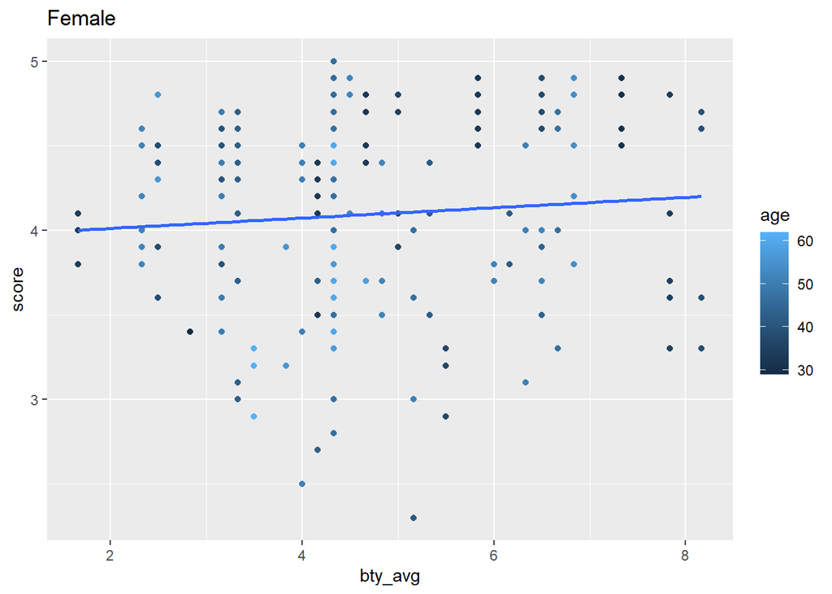

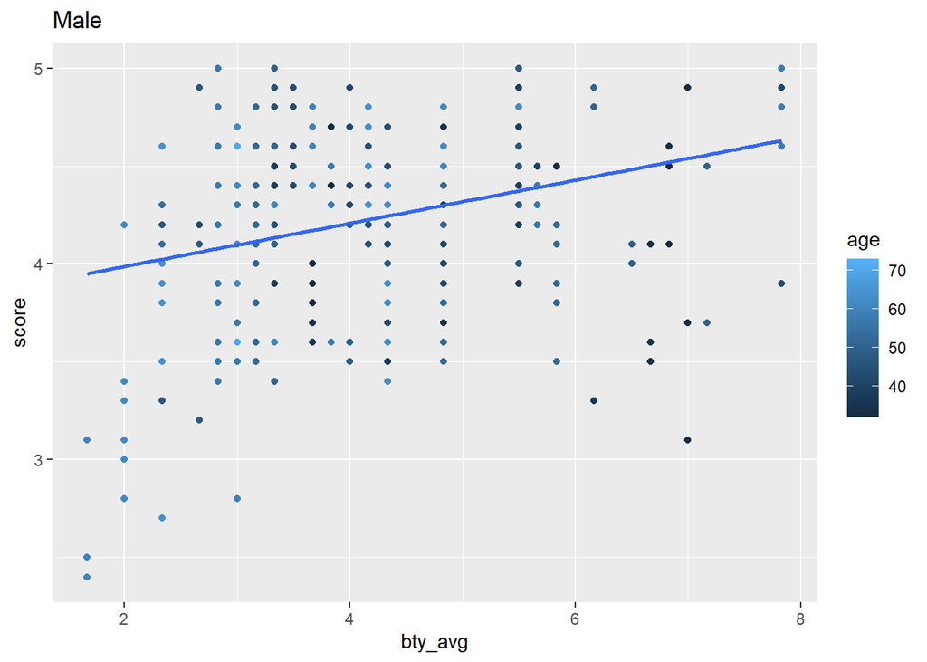

```r
my_iterations |> pull(my_plot)
```

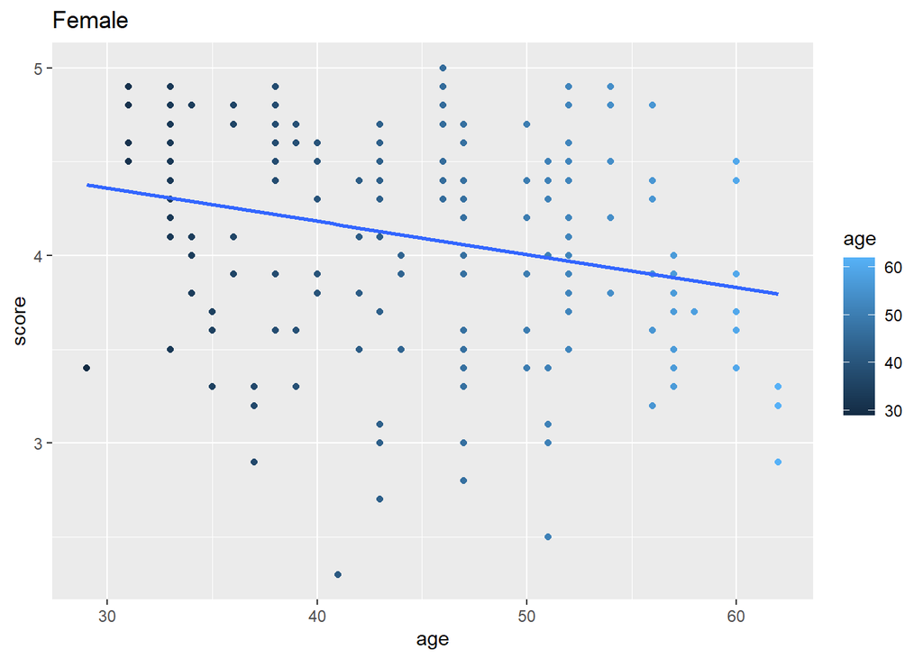

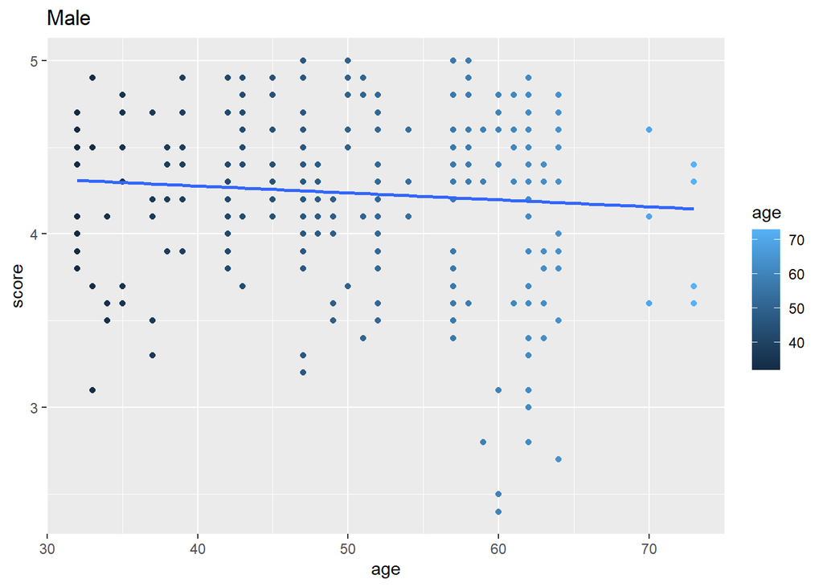

```r
my_iterations |> pull(my_plot_age)
```

### different data

One more example of tidying model output with {broom}.

```r
lm(mass ~ height, data = starwars)
```

```
Call:
lm(formula = mass ~ height, data = starwars)

Coefficients:
(Intercept)       height
    -11.487        0.624
```

```r
lm(mass ~ height, data = starwars) |>  summary()
```

```
Call:
lm(formula = mass ~ height, data = starwars)

Residuals:
    Min      1Q  Median      3Q     Max
 -60.95  -29.51  -20.83  -17.65 1260.29

Coefficients:
            Estimate Std. Error t value Pr(>|t|)
(Intercept) -11.4868   111.3842  -0.103    0.918
height        0.6240     0.6262   0.997    0.323

Residual standard error: 169.5 on 57 degrees of freedom
  (28 observations deleted due to missingness)
Multiple R-squared:  0.01712,   Adjusted R-squared:  -0.0001194
F-statistic: 0.9931 on 1 and 57 DF,  p-value: 0.3232
```

```r
lm(mass ~ height, data = starwars) |>
  broom::tidy()
```

| term | estimate | std.error | statistic | p.value |
| --- | --- | --- | --- | --- |
| (Intercept) | -11.4868157 | 111.3841576 | -0.1031279 | 0.9182234 |
| height | 0.6240033 | 0.6261744 | 0.9965328 | 0.3232031 |

```r
lm(mass ~ height, data = starwars) |>
  broom::glance()
```

| r.squared | adj.r.squared | sigma | statistic | p.value | df | logLik | AIC | BIC | deviance | df.residual | nobs |
| --- | --- | --- | --- | --- | --- | --- | --- | --- | --- | --- | --- |
| 0.01712407 | -0.0001193655 | 169.4673 | 0.9930776 | 0.3232031 | 1 | -385.527 | 777.0539 | 783.2865 | 1636992 | 57 | 59 |

## Drawing a regression line with the fitted data

```r
score_model$fitted.values |>
  head()
```

```
       1        2        3        4        5        6
4.213523 4.213523 4.213523 4.213523 4.080249 4.080249
```

### {broom} augment

The fitted values can also be accessed via `broom::augment()`

`.fitted` & `.residuals`

```r
fit <- lm(mpg ~ wt, data = mtcars)

tidy(fit)
```

| term | estimate | std.error | statistic | p.value |
| --- | --- | --- | --- | --- |
| (Intercept) | 37.285126 | 1.877627 | 19.857575 | 8.241799e-19 |
| wt | -5.344472 | 0.559101 | -9.559044 | 1.293959e-10 |

```r
tidy_fit <- augment(fit)
tidy_fit
```

| .rownames | mpg | wt | .fitted | .resid | .hat | .sigma | .cooksd | .std.resid |
| --- | --- | --- | --- | --- | --- | --- | --- | --- |
| Mazda RX4 | 21.0 | 2.620 | 23.282611 | -2.2826106 | 0.04326896 | 3.067494 | 1.327407e-02 | -0.76616765 |
| Mazda RX4 Wag | 21.0 | 2.875 | 21.919770 | -0.9197704 | 0.03519677 | 3.093068 | 1.723963e-03 | -0.30743051 |
| Datsun 710 | 22.8 | 2.320 | 24.885952 | -2.0859521 | 0.05837573 | 3.072127 | 1.543937e-02 | -0.70575249 |
| Hornet 4 Drive | 21.4 | 3.215 | 20.102650 | 1.2973499 | 0.03125017 | 3.088268 | 3.020558e-03 | 0.43275114 |
| Hornet Sportabout | 18.7 | 3.440 | 18.900144 | -0.2001440 | 0.03292182 | 3.097722 | 7.599578e-05 | -0.06681879 |
| Valiant | 18.1 | 3.460 | 18.793255 | -0.6932545 | 0.03323551 | 3.095184 | 9.210650e-04 | -0.23148309 |
| Duster 360 | 14.3 | 3.570 | 18.205363 | -3.9053627 | 0.03544265 | 3.008664 | 3.131386e-02 | -1.30552216 |
| Merc 240D | 24.4 | 3.190 | 20.236262 | 4.1637381 | 0.03127502 | 2.996697 | 3.113918e-02 | 1.38889709 |
| Merc 230 | 22.8 | 3.150 | 20.450041 | 2.3499593 | 0.03140238 | 3.066058 | 9.961857e-03 | 0.78392687 |
| Merc 280 | 19.2 | 3.440 | 18.900144 | 0.2998560 | 0.03292182 | 3.097435 | 1.705808e-04 | 0.10010803 |

[output cut: 22 more lines]

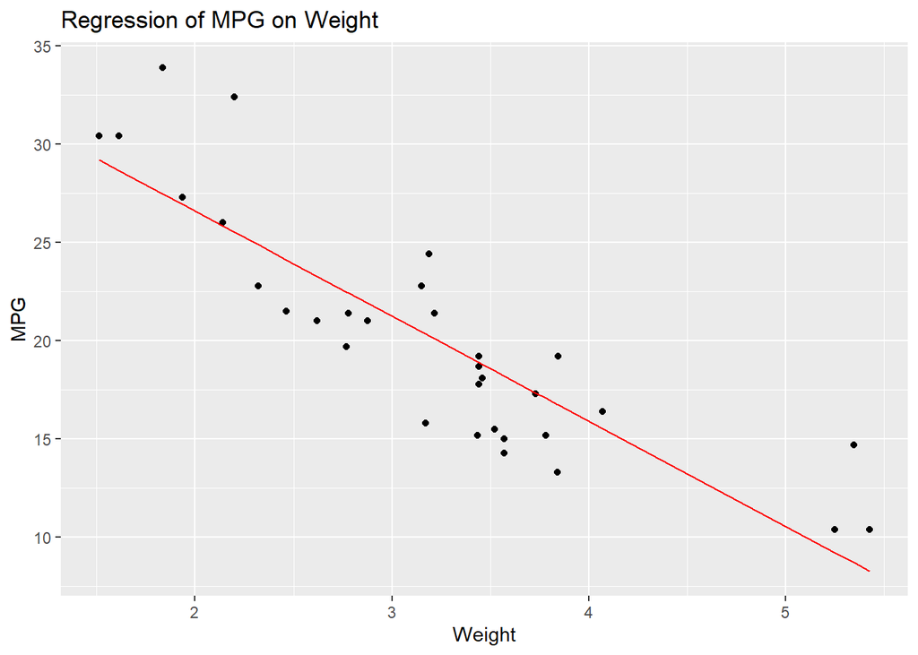

```r
mtcars |>
  ggplot(aes(x = wt, y = mpg)) +
  geom_point() +
  geom_line(data = tidy_fit, aes(y = .fitted), color = "red") +
  labs(title = "Regression of MPG on Weight",
       x = "Weight",
       y = "MPG")
```

## Tidymodels (Prediction) / *statistical learning*

> Different from inference, prediction will often fit many models. To avoid copy/paste inefficiencies and barriers, we’ll want to leverage iteration. Enter {purrr} and {tidymodels} — Alexander (2023)

The tidymodels package is designed to **scale well ; enable thinking about overfitting ; support *model* evaluation**. As with the grammars of {dplyr} (data wrangling) and {ggplot} (graphics / visualization), {tidymodels} has a “grammar that allows us to easily fit a variety of models” (Alexander 2023)

```r
library(tidymodels)
# library(arrow)
```

import parquet data from Github

```r
foo_df <- arrow::read_parquet("https://github.com/RohanAlexander/telling_stories/raw/main/outputs/data/running_data.parquet")
```

When we focus on prediction we worry about over-fitting because over-fitting diminishes the veracity and validity of our claims. A partial mitigation is **spliting our data** to create training and test datasets. 80% of our data is for **training** to estimate the parameters of our model (inform our estimates of the coefficients). The **testing data** will be used to evaluate our model. Then we use the test-training split to enable the opportunity to build an appropriate model.

Training data must not bleed into test data. This is called leakage.

```r
# sim_run_data <-
#   read_parquet(file = "outputs/data/running_data.parquet")
sim_run_data <- foo_df

set.seed(853)

sim_run_data_split <-
  initial_split(
    data = sim_run_data,
    prop = 0.80
  )

sim_run_data_split
```

```
<Training/Testing/Total>
<160/40/200>
```

```r
sim_run_data_train <- training(sim_run_data_split)
sim_run_data_test <- testing(sim_run_data_split)

sim_run_data_test |> head()
```

| five_km_time | marathon_time | was_raining | humidity | weather_conditions |
| --- | --- | --- | --- | --- |
| 19.6 | 156.3 | No | Low | No rain, not humid |
| 29.3 | 258.6 | No | Low | No rain, not humid |
| 22.9 | 191.5 | No | Low | No rain, not humid |
| 21.1 | 192.4 | No | Low | No rain, not humid |
| 20.0 | 174.0 | No | Low | No rain, not humid |
| 25.2 | 199.0 | No | Low | No rain, not humid |

### STEPS

specify a model. In this case `linear_reg()`

1. specify the type of linear regression with `set_engine()`. In this case *multiple linear regression*
2. specify the fit `fit()`.

> While this requires considerably more infrastructure than the base R approach detailed above, the advantage of this approach is that it can be used to fit many models

```r
sim_run_data_first_model_tidymodels <-
  linear_reg() |>
  set_engine(engine = "lm") |>
  fit(
    marathon_time ~ five_km_time + was_raining,
    data = sim_run_data_train
  )
```

```r
sim_run_data_first_model_tidymodels |>
  tidy()
```

| term | estimate | std.error | statistic | p.value |
| --- | --- | --- | --- | --- |
| (Intercept) | 5.681715 | 8.4224984 | 0.6745878 | 5.009298e-01 |
| five_km_time | 8.265975 | 0.3702119 | 22.3276858 | 1.373190e-50 |
| was_rainingYes | 16.304121 | 3.4138999 | 4.7758051 | 4.074651e-06 |

Can also use {tidymodels} for logistic regression (classification models) ; Poisson regression.

See Also: [Parsnip](https://parsnip.tidymodels.org/)- a unified interface to models that can be used. Try out a range of models

See Also: [recipes](https://recipes.tidymodels.org/)

See Also: [workflows](https://workflows.tidymodels.org/)

See Also: [tune](https://tune.tidymodels.org/)

See Also: [yardstick](https://yardstick.tidymodels.org/)

### k-fold cross-validation

Evaluate a model with resampling, a method that can address prediction problems resulting from small datasets.

- https://www.tidymodels.org/start/resampling/#resampling
- aka [V-fold corss-validation](https://rsample.tidymodels.org/reference/vfold_cv.html) using {[rsample](https://rsample.tidymodels.org/)}

### Poisson regression

- https://tellingstorieswithdata.com/27-prediction.html#poisson-regression

### Lasso regression

- LASSO Regression using tidymodels and *The Office - [Silge blog](https://juliasilge.com/blog/lasso-the-office/)*
- A first model: [Penalized Logistic Regression](https://www.tidymodels.org/start/case-study/#first-model)
- https://tellingstorieswithdata.com/27-prediction.html

## References

Alexander, Rohan. 2023. “Telling Stories with Data,” June. https://doi.org/10.1201/9781003229407.

Lipovetsky, Stan. 2020. “Statistical Inference via Data Science: A Modern Dive Into R and the Tidyverse.” *Technometrics* 62 (2): 1–283. https://doi.org/10.1080/00401706.2020.1744908.